# Final Project

## DATA WRANGLING 2

I wish to do an analysis to see how many areas that meet each of the 4 criteria.

First, I need to change the commas in the dataframes, so R can read it properly.

```r
samletkategoriseret$Dømte <- gsub(",",".", c(samletkategoriseret$Dømte))
samletkategoriseret$Uddannelse <- gsub(",",".", c(samletkategoriseret$Uddannelse))
samletkategoriseret$Indkomst <- gsub(",",".", c(samletkategoriseret$Indkomst))
samletkategoriseret$Etnicitet <- gsub(",",".", c(samletkategoriseret$Etnicitet))
samletkategoriseret$Ledighed <- gsub(",",".", c(samletkategoriseret$Ledighed))
```

Second, I create an object for each criteria using the length argument to summarize the number of areas that meet each criteria.

```r
n_dømte <- length(samletkategoriseret[samletkategoriseret$Dømte >=2.03, "Dømte"])
n_ledighed <- length(samletkategoriseret[samletkategoriseret$Ledighed > 40, "Ledighed"])
n_uddannelse <- length(samletkategoriseret[samletkategoriseret$Uddannelse > 60, "Uddannelse"])
n_indkomst <- length(samletkategoriseret[samletkategoriseret$Indkomst < 55, "Indkomst"])
```

I create a new dataframe that contains a coloumn with these lengths and a coloumn with the names of the criterias

```r
n_alle <- c(n_dømte, n_ledighed, n_uddannelse, n_indkomst)
kriterier <- c("Crime Rate","Employment","Education","Income")

criteriacount <- data.frame(n_alle, kriterier)
```

## PLOTTING 2

Now, it is easy to plot.

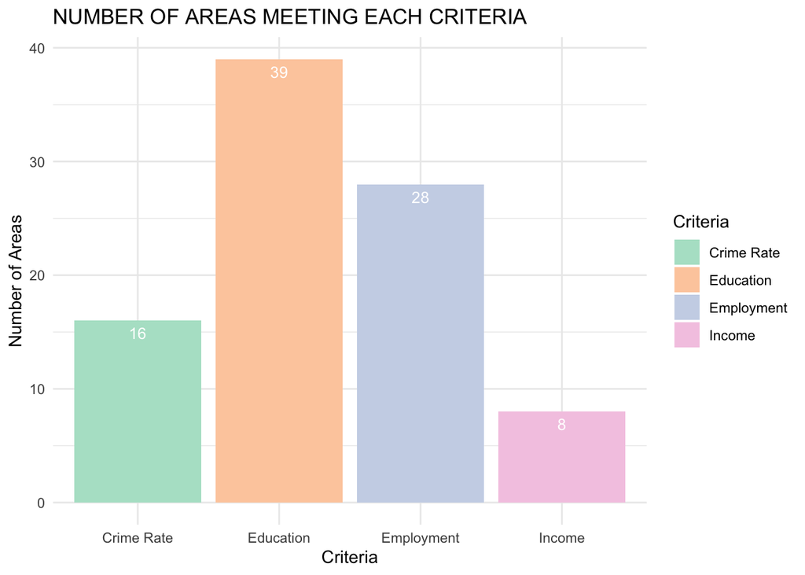